# Tree_Methods slides

1. Morning
   - Data Modelling & Cross Validation
   - data leakage & dependent data
   - imbalanced data (example in python)
   - study: Ebanking Fraud
   - Q&A
1. Afternoon
   - Data Basics & historical perspective
   - Linear Regression
   - **Trees**
   - house prices (regression example in python)
   - Clustering
   - bonus: Hyperparameter Optimization and AutoML
   - Q&A

## Why trees?

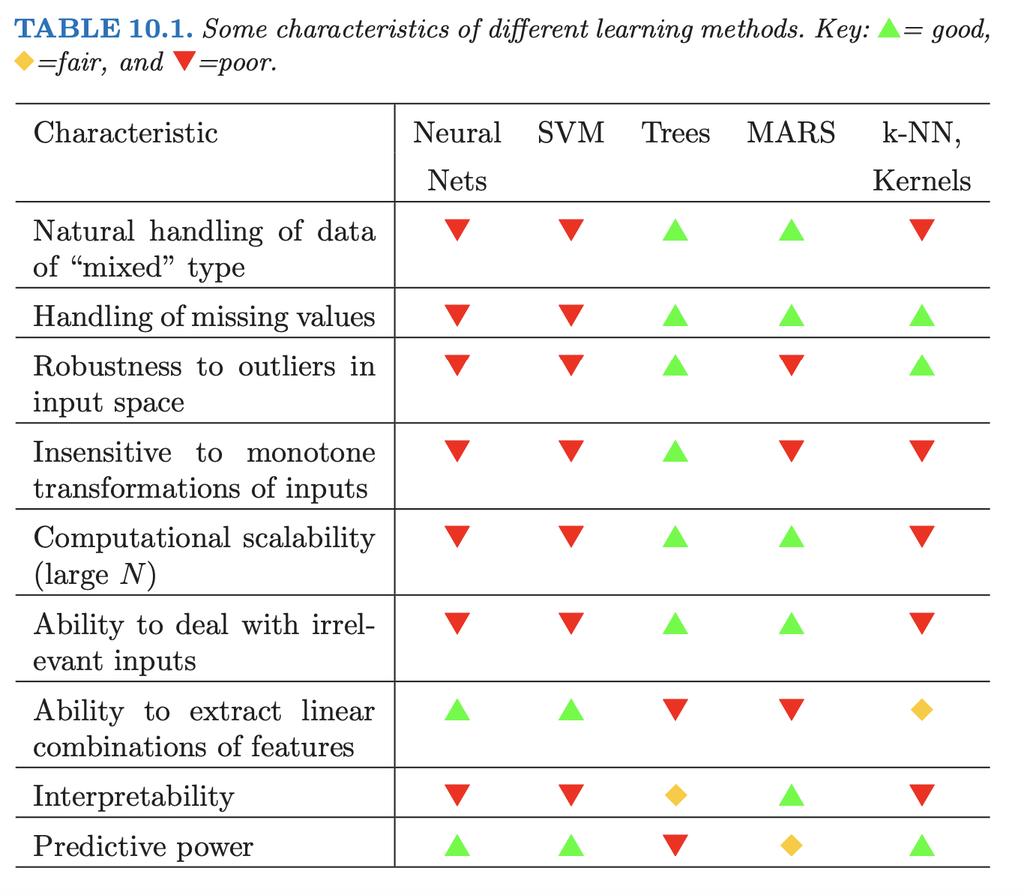

In nachfolgender Graphik wird demonstriert, wie ein decision-tree classifier nach und nach den Input-Variablen-Raum unterteilt um möglichst reine Unterräume zu erhalten. Diese Unterräume entsprechen den jeweiligen Knoten im Baum (nodes), bzw. den Blättern.  
Wichtig ist, dass diese splits auf einer Variablen immer **orthogonal** sind.

[output not shown]

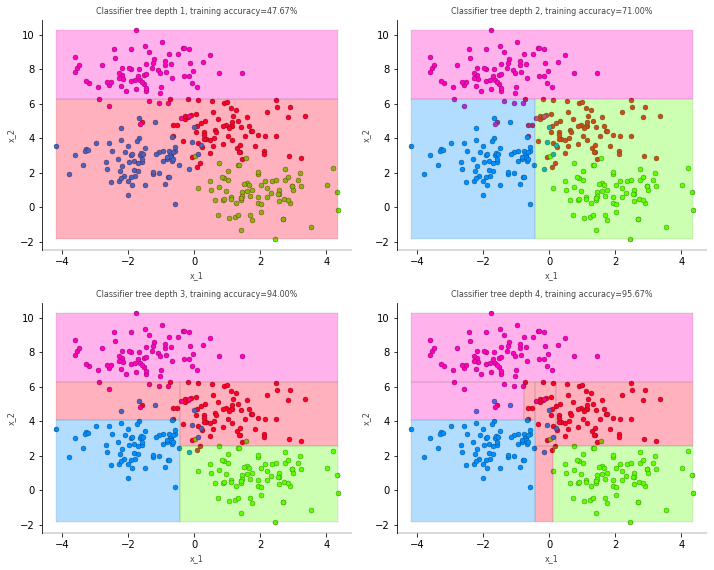

Dies ist der decision-trees mit den splits, wie sie oben dargestellt sind.

[output not shown]

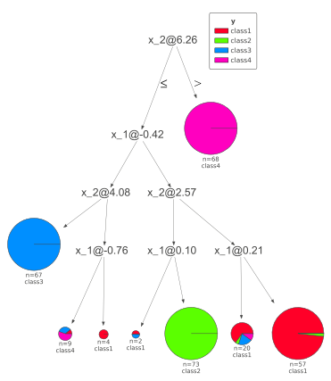

### Compare to linear Regression (logistic regression in this case)

Logistic Regression only works for binary classes. But we can always classify **o**ne class **v**ersus the **r**est (ovr) of the other classes - this allows multiclass classification with logistic regression.  
We can see, whereas the classification tree can approximate **non-linear seperating lines** with many rectangular splits, the logistic regression can only do linear splits.

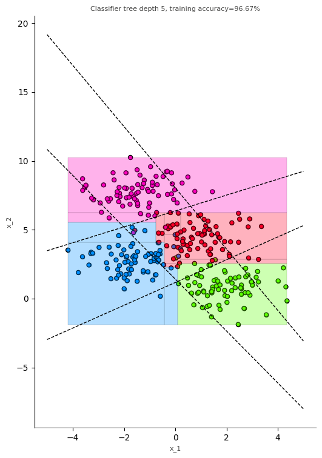

### Splitting criteria

For most variants of classification trees, there are basically two important splitting statistics:

1. Gini Impurity
2. Entropy

**Gini Impurity**

\begin{equation} \text{Gini} = \sum_i^n p_i (1-p_i) \end{equation}

For a binary classification problem (either 0 or 1) the Gini-Index is:

\begin{equation} \text{Gini} = p_1 (1-p_1) + p_2 (1-p_2) \end{equation}

Here, $p_1$ is the purity of the respective node in the tree.

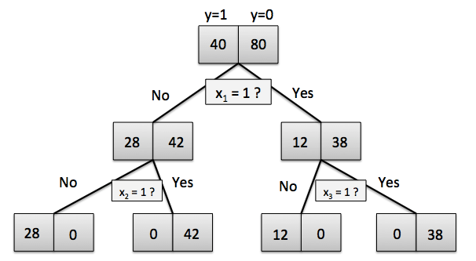

At the root of the tree, we have the following impurities for class 1 and class 0:  
\begin{eqnarray*} p_{01} =& \frac{40}{120} = 0.3333\\ p_{00} =& \frac{80}{120} = 0.6666 \end{eqnarray*} The Gini-Impurity at the root is given by: \begin{equation} \text{Gini}_{0} = p_{01}\cdot (1-p_{01}) + p_{00}\cdot (1-p_{00}) = 0.4444 \end{equation}

Next we compute the Gini-Impurities $\text{Gini}_1$ and $\text{Gini}_2$ for the child-nodes after the first split: \begin{eqnarray*} p_{11} =& \frac{28}{70} = 0.4\\ p_{10} =& \frac{42}{70} = 0.6 \end{eqnarray*} The Gini-Impurity of the first child node is given by: \begin{equation} \text{Gini}_{1} = p_{11}\cdot (1-p_{11}) + p_{10}\cdot (1-p_{10}) = 0.48 \end{equation} For the second child node, we get: \begin{eqnarray*} p_{21} =& \frac{12}{50} = 0.24\\ p_{20} =& \frac{38}{50} = 0.76 \end{eqnarray*} The Gini-Impurity of the second child node is given by: \begin{equation} \text{Gini}_{2} = p_{21}\cdot (1-p_{21}) + p_{20}\cdot (1-p_{20}) = 0.3648 \end{equation}

In the left child node, there are 70 observations, whereas in the right child node, we only have 50 observations. To compute the overall Gini-impurity after the first split, we have the weight the Gini-Impurities of the two child-nodes with the fraction of observations they represent:

We see, the impurity could be reduced by the first split from $\,\mathbf{0.4444}\,$ to $\,\mathbf{0.4320}\,$.

Instead of Gini-Impurity, we could just take classification error as a criterion - this seems most intuitive:  
The classification error in the root node is given by:

\begin{equation} p_0 = \frac{40}{120} = \mathbf{0.333} \end{equation}

The classification error in the first child-node is:  
\begin{equation} p_1 = \frac{28}{70} = 0.4 \end{equation} And the classification error in the second child-node is given by:  
\begin{equation} p_2 = \frac{12}{50} = 0.24 \end{equation} Now, to compute the reduction in classifiication-error, we have again to weigh the two nodes by the number of observations the contain:

Classification-error after the first split is: \begin{equation} \frac{70}{120} \cdot 0.4 + \frac{50}{120} \cdot 0.24 = \mathbf{0.333} \end{equation}  
Hence, the split is not reducing the classification-error. But without the first split, the following splits that subsequenly lead to zero classification error would no be possible.

# Genetic Algorithms

[figure not shown]

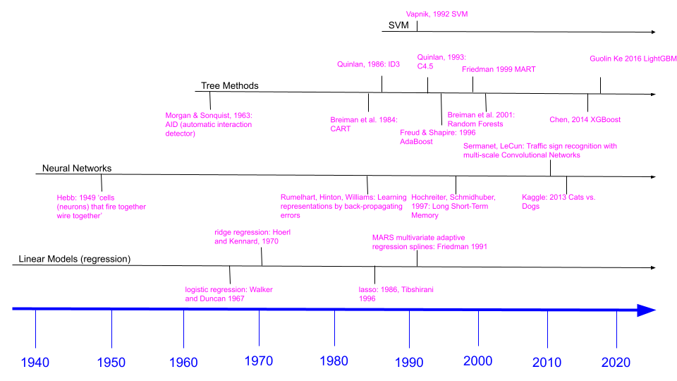

[figure not shown]

### Evolutionary Decision Trees:

Genetic Algorithms try to mimic the genetic recombination happening in sexual reproduction:

- Crossing Over: random recombination between the paired chromosomes inherited from each of one's parents, generally occurring during meiosis (wiki);
- fertilization: haploid chromosomes from a random mother and a random father form a new diploid set of chromosomes
- mutation: randomly, some genes may change accidentally

Survival of the Fittest:

- only a certain number of the offspring passes the evolutionary bottleneck (the best adapted ones + some randomness)
- the survivors form the next parent generation with probability proportional to their fitness

**Applied to decision trees on can:**

- start growing a generation of decision trees, and recombine the fittest trees
- grow and prune decision trees with evolutionary principles

### my opinion about evolutionary algorithms:

Before the advent of modern machine-learning algorithms, most algorithms (classification-trees) where optimized in a hill-climbing fashion: **straight to the top**  
But as we all know, the seemingly shortest path is not necessarily the best one.  
The straight path may end, for example, on a steep cliff, i.e the algorithm finds a local optimum that is not identical with the global optimum.  
Evolutionary optimization methods are a way to explore the search space in a more random fashion - avoiding getting stuck in local optima and hopefully finding the local optimum.

**BUT**:

- There is no guarantee that these algorithms will succeed.
- The search can be very long-lasting.

**AND**:

- Modern Algorithms - as for example Random Forest or Gradient Boosting Trees - have randomness build in.

## Random Forest

Random Forest is an example of classifier Bootstrap Aggregation or bagging.

### Pros of Random Forest:

- trees can be trained independently: easy to parallelize
- classification and regression possible
- all other pros of trees like: handling of missing values, insensitive to outliers, numerical and categorical data, etc..
- can give a variance estimate (confidence intervals): mean prediction and variance of prediction (see SMAC in AutoML)
- averaging allows for arbitrary non-linear relationships

### Cons of Random Forest:

- black box algorithm: hard to interpret; (see feature importance)

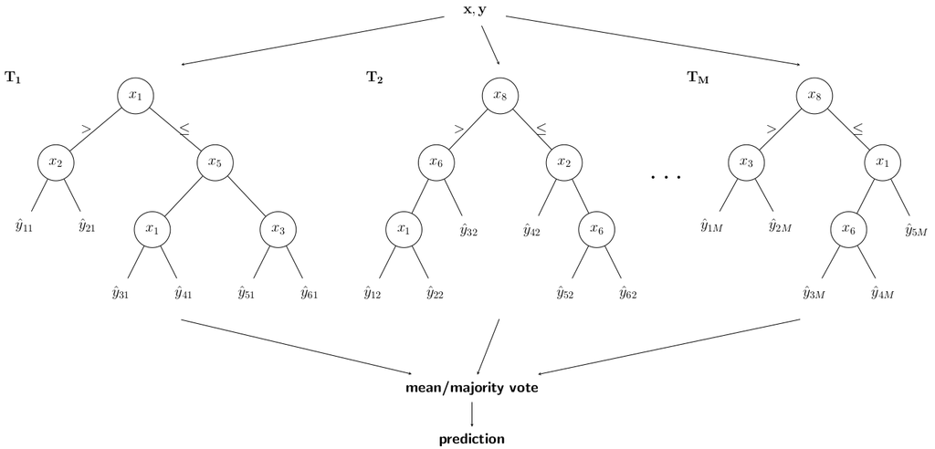

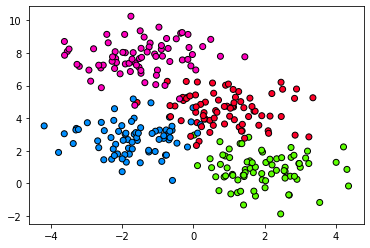

[figure not shown]

# Gradient Boosted Trees

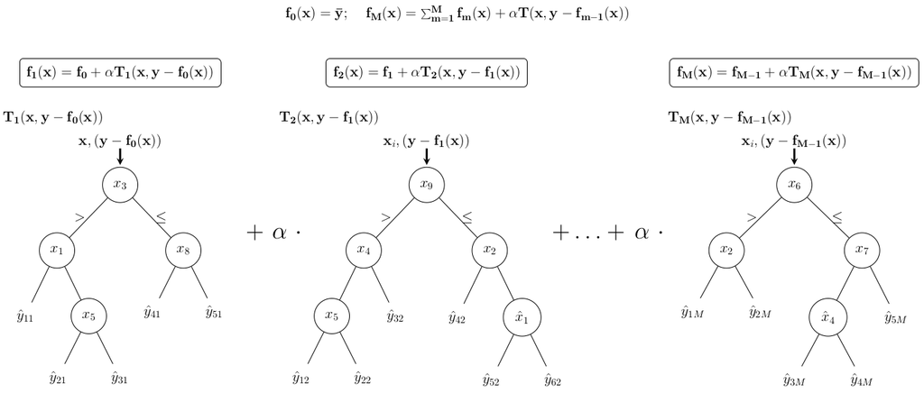

### Explanation of Gradient Boosted Trees:

- we start with a prediction $f_0(x)$, i.e. the mean of $y$ ($\bar{y}$) for regression or the most frequent class in case of classification
- the difference between the actual values $y_i$ and our initial start value $f_0(x)$ (residuals) is to be predicted by the first tree $T_1$; the tree uses the variables $\pmb{X}$ to find a rule to group similar residuals in common nodes.
- the new prediction of the tree $T_1$ is added to our initial start value and weighted by the learning parameter; now we get our prediction at iteration $1$: $f_1(x) = f_0 + \alpha T_1(\pmb{x}, y - f_0(x))$, i.e. we train a tree $T_1$ to correctly classify the residuals $y - f_0(x)$ with a rule induced on $\pmb{x}$ -- our variables. The result of this tree is weighted with leraning-rate $\alpha$ and added to the current estimate $f_0(x)$.
- this procedure is repeated until we can not find any more trees that substantially reduce our error or until the maximum number of iterations is reached

Since there are many different loss-functions possible for Gradient Boosting Trees (not only regression), we are looking for a more general formula that defines the best update to our current prediction made by the next tree.

## most important parameters for stochastic gradient-boosting:

- **learning_rate**: the factor $\alpha$ in the above graphic
- **subsample**: takes part of the data without replacement; prevents overfitting
- **feature_fraction**: select a subset of the features for the next tree; prevents overfitting
- **num_leaves**: number of leaves; lightgbm fits level-wise and leaf-wise; prevents overfitting
- **max_depth**: number of levels to grow the tree; prevents overfitting
- **num_iterations**: number of trees to grow
- **max_bin**: in lightgbm all features are discretized by binning them; the number of bins for a feature is given by **max_bin** (this is what makes lightgbm super-fast)
- **lambda_l1/lambda_l2**: regularizes the leaf-weights; **excurs**: the result assigned to all cases that end up in one leaf is called the weight; for regression this is a continuous value and also for classification since the result is ultimately passed through a sigmoid-function that assigns then values between 0 and 1;

For a speed comparison between lightgbm and xgboost see e.g. [results from 2017](https://medium.com/implodinggradients/benchmarking-lightgbm-how-fast-is-lightgbm-vs-xgboost-15d224568031) Meanwhile xgboost catched up with lightgbm.  
A good paper, describing how the features of lightgbm have beed added to xgboost [is this one.](https://drive.google.com/file/d/0B0c0MbnP6Nn-eUNRRkVOOGpkbFk/view)  
Less mathematical however, is this report here: https://everdark.github.io/k9/notebooks/ml/gradient_boosting/gbt.nb.html#5_lightgbm